# Digit Recognizer in R

## Introduction

The goal of this project is to take an image of a handwritten single digit, and determine what that digit is. The data for this Project was taken from the MNIST dataset.

The MNIST (“Modified National Institute of Standards and Technology”) dataset is a classic within the Machine Learning community that has been extensively studied. More detail about the dataset, including Machine Learning algorithms that have been tried on it and their levels of success, can be found at http://yann.lecun.com/exdb/mnist/index.html.

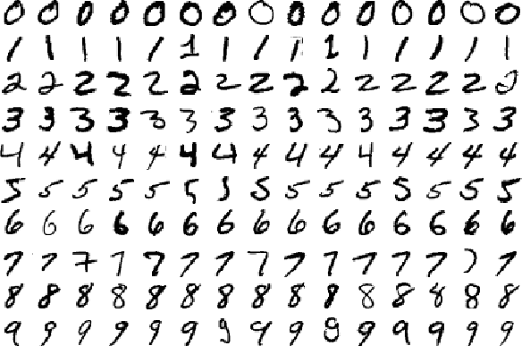

Image provided by the MNIST handwritten databse

```r
#install.packages("readr")
library(readr)
setwd("/Users/rameshthulasiram/Documents/yams_predictiveAnalytics/FinalProject_digitrecognizer")
train <- read_csv("train.csv")
test <- read_csv("test.csv")
head(train[1:10])
```

```
##   label pixel0 pixel1 pixel2 pixel3 pixel4 pixel5 pixel6 pixel7 pixel8
## 1     1      0      0      0      0      0      0      0      0      0
## 2     0      0      0      0      0      0      0      0      0      0
## 3     1      0      0      0      0      0      0      0      0      0
## 4     4      0      0      0      0      0      0      0      0      0
## 5     0      0      0      0      0      0      0      0      0      0
## 6     0      0      0      0      0      0      0      0      0      0
```

As always, first I read in data and take a look at it. The `train.csv` has one digit label column and 784 columns with pixel color values that go from 0 to 255.

```r
dim(train) #29400 obs. of  784 variables:
```

```
## [1] 42000   785
```

```r
dim(test) # 28000 obs. of  784 variables
```

```
## [1] 28000   784
```

## Challenges in traditional Machine Learning:

*Feature extraction - the programmer needs to tell the computer what kinds of things it should be looking for that will be informative in making a decision. Feeding the algorithm raw data rarely ever works, so feature extraction is a critical part of the traditional machine learning workflow. This places a huge burden on the programmer, and the algorithm’s effectiveness relies heavily on how insightful the programmer is. For complex problems such as object recognition or handwriting recognition, this is a huge challenge.

## There are 3 ways to handle such large datasets:

1. Deep learning : Deep learning is one of the only methods by which we can circumvent the challenges of feature extraction. This is because deep learning models are capable of learning to focus on the right features by themselves, requiring little guidance from the programmer. This makes deep learning an extremely powerful tool for modern machine learning. Deep learning is a form of machine learning that uses a model of computing that’s very much inspired by the structure of the brain. Hence we call this model a neural network.
2. PCA + Neural Networks : PCA is a classy way to reduce the dimensionality of the data, while (purportedly) keeping most of the information. PCA uses orthogonal transformation to convert a set of observations of possibly correlated variables into a set of values of linearly uncorrelated variables called principal components.
3. Random Forests : Ensemle learning method that Averages multiple decision trees each created on different random samples of rows and samples.

## Table of Contents

- 1. Data Preprocessing
- 2. Train, Predict and Save
- 3. Conclusion

## Data Preprocessing

We can quickly plot the pixel color values to obtain a picture of the digit.

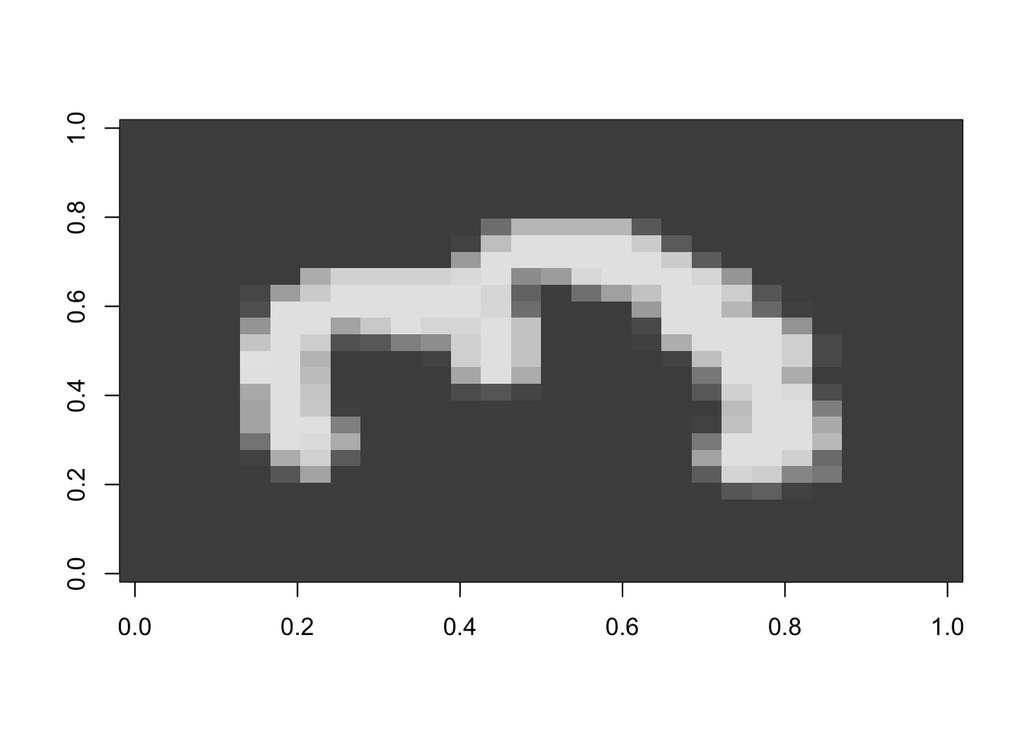

```r
# Create a 28*28 matrix with pixel color values
m = matrix(unlist(train[10,-1]),nrow = 28,byrow = T)
# Plot that matrix
image(m,col=grey.colors(255))
```

This image needs to be rotated to the right. I will rotate the matrix and plot a bunch of images.

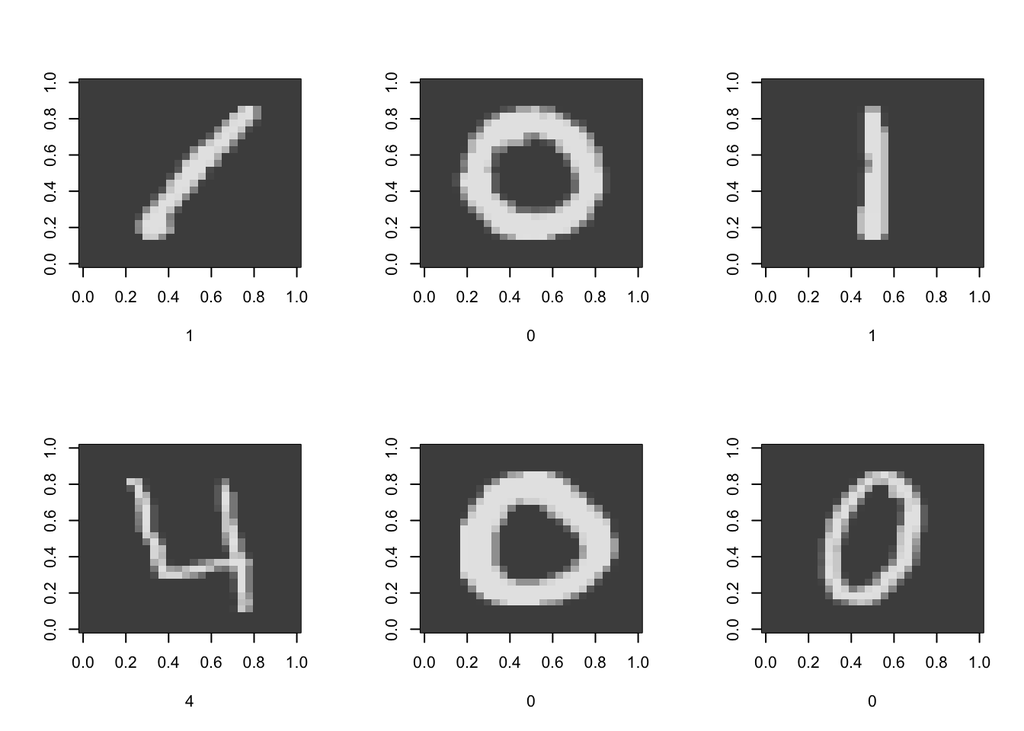

```r
rotate <- function(x) t(apply(x, 2, rev)) # reverses (rotates the matrix)

# Plot a bunch of images
par(mfrow=c(2,3))
lapply(1:6,
    function(x) image(
                    rotate(matrix(unlist(train[x,-1]),nrow = 28,byrow = T)),
                    col=grey.colors(255),
                    xlab=train[x,1]
                )
)
```

```r
par(mfrow=c(1,1)) # set plot options back to default
```

## Deep Learning using H2O

## Train, Predict and Save

h2o uses virtual Java clusters to do its work and achieve amazingly quick performance. Below code initializes a local cluster.I referred to documentation on https://github.com/h2oai/h2o-3/blob/master/h2o-docs/src/booklets/v2_2015/PDFs/online/R_Vignette.pdf

```r
#install.packages("h2o")
library(h2o)
## start a local h2o cluster
localH2O = h2o.init(max_mem_size = '6g', # use 6GB of RAM of *GB available
                    nthreads = -1) # use all CPUs- strongly recommended.
```

[output not shown]

Now, I just convert the `train` and `test` sets into the h2o format and set up the model. The `h2o.deeplearning()` function has lots of configurable arguments. For demonstration I went with a two layer neural network with 100 nodes and 0.5 dropout ratio in each. While I could specify a learning rate I decided not to because it is adaptive by default which should result in an improved accuracy score.

## Data preparation/Data munging

Transfer the data from R to H2O instance.

```r
## MNIST data as H2O
train[,1] = as.factor(train[,1]) # convert digit labels to factor for classification
train_h2o = as.h2o(train)
test_h2o = as.h2o(test)
## set timer
s <- proc.time()
```

## Train the model using Deep learning algorithm:

h20.deeplearning - performs deep learning neural networks on an H2O parsed Data object.

```r
## train model
model = h2o.deeplearning(x = 2:785,  # column numbers for predictors
                   y = 1,   # column number for label
                   training_frame = train_h2o, # data in H2O format
                   activation = "RectifierWithDropout", # algorithm
                   input_dropout_ratio = 0.2, # % of inputs dropout
                   hidden_dropout_ratios = c(0.5,0.5), # % for nodes dropout
                   balance_classes = TRUE,
                   hidden = c(100,100), # two layers of 100 nodes
                   momentum_stable = 0.99,
                   nesterov_accelerated_gradient = T, # use it for speed
                   epochs = 15) # no. of epochs
```

## Model Accuracy and error rate

```r
## print confusion matrix
h2o.confusionMatrix(model)
```

```
## Confusion Matrix: vertical: actual; across: predicted
##          0   1    2   3    4   5   6    7   8    9  Error          Rate
## 0      972   0    1   4    1   4   5    9   3    0 0.0270 =    27 / 999
## 1        0 935    4   9    0   0   2    6   3    2 0.0271 =    26 / 961
## 2        1   1  965   2    1   1   5   22   1    1 0.0350 =  35 / 1,000
## 3        0   0   13 930    0  10   0   13   3    5 0.0452 =    44 / 974
## 4        0   0   11   0  997   1   5    2   2   27 0.0459 =  48 / 1,045
## 5        3   2    7  12    1 924   8   11   3    2 0.0504 =    49 / 973
## 6        5   0    4   0    1   6 940   14   1    0 0.0319 =    31 / 971
## 7        1   3   12   3    3   0   0 1011   0    8 0.0288 =  30 / 1,041
## 8        0   8    5   5    5  15   3    8 916    2 0.0527 =    51 / 967
## 9        6   0    1  10   17   7   2   35   1  957 0.0763 =  79 / 1,036
## Totals 988 949 1023 975 1026 968 970 1131 933 1004 0.0421 = 420 / 9,967
```

```r
## print time elapsed
s - proc.time()
```

```
##     user   system  elapsed
##   -1.188   -0.077 -103.638
```

## Model Scoring

```r
## classify test set
h2o_y_test <- h2o.predict(model, test_h2o)
```

```r
## convert H2O format into data frame and  save as csv
df_y_test = as.data.frame(h2o_y_test)
df_y_test = data.frame(ImageId = seq(1,length(df_y_test$predict)), Label = df_y_test$predict)
write.csv(df_y_test, file = "submission-r-h2o.csv", row.names=F)

## shut down virutal H2O cluster
h2o.shutdown(prompt = F)
```

```
## [1] TRUE
```

### Interpretation

While using R to approach this problem I spent virtually no time on setting up the framework (in contrast to Python where it unpleasantly lasted). The exploratory analysis would have been quick and easy to do as well if I did any. However, I could not find an implementation of convolutional neural network in R. As a result, I settled for a two layer NN.

The best accuracy score I could get using the NN setup above was 1 - 0.0421391 = 0.9578609.

R is great when it comes to exploratory analysis and data visualization. Since, everything is done in the memory there are immediate limits imposed on the scale of the problem. One of the ways to cope with this problem is to produce extensions like ’h2o` which for examples utilizes virtual Java clusters to do its work fast.

# Using PCA and neural network

```r
X <- train[,-1]
Y <- train[,1]
trainlabel <- train[,1]
#Reducing Train using PCA
Xreduced <- X/255
Xcov <- cov(Xreduced)
pcaX <- prcomp(Xcov)
# Creating a datatable to store and plot the
# No of Principal Components vs Cumulative Variance Explained
vexplained <- as.data.frame(pcaX$sdev^2/sum(pcaX$sdev^2))
vexplained <- cbind(c(1:784),vexplained,cumsum(vexplained[,1]))
colnames(vexplained) <- c("No_of_Principal_Components","Individual_Variance_Explained","Cumulative_Variance_Explained")
#Plotting the curve using the datatable obtained
plot(vexplained$No_of_Principal_Components,vexplained$Cumulative_Variance_Explained, xlim = c(0,100),type='b',pch=16,xlab = "Principal Componets",ylab = "Cumulative Variance Explained",main = 'Principal Components vs Cumulative Variance Explained')
#Datatable to store the summary of the datatable obtained
vexplainedsummary <- vexplained[seq(0,100,5),]
vexplainedsummary
```

```
##     No_of_Principal_Components Individual_Variance_Explained
## 5                            5                  7.168129e-02
## 10                          10                  1.804312e-02
## 15                          15                  8.139920e-03
## 20                          20                  4.332336e-03
## 25                          25                  2.564184e-03
## 30                          30                  1.539869e-03
## 35                          35                  1.042933e-03
## 40                          40                  7.111902e-04
## 45                          45                  4.828504e-04
## 50                          50                  3.355017e-04
## 55                          55                  2.571440e-04
## 60                          60                  1.984946e-04
## 65                          65                  1.497567e-04
## 70                          70                  1.163386e-04
```

[output cut: 27 more lines]

```r
#Storing the vexplainedsummary datatable in png format for future reference.
library(gridExtra)
```

[figure not shown]

```r
png("datatablevaraince explained.png",height = 800,width =1000)
p <-tableGrob(vexplainedsummary)
grid.arrange(p)
dev.off()
```

```r
Xfinal <- as.matrix(Xreduced) %*% pcaX$rotation[,1:45]
dim(X)
```

```
## [1] 42000   784
```

```r
dim(Xfinal)
```

```
## [1] 42000    45
```

```r
#Making training labels as factors
trainlabel <- as.factor(trainlabel)
library(nnet)
Y <- class.ind(Y)
print(X[1:5,1:5])
```

```
##   pixel0 pixel1 pixel2 pixel3 pixel4
## 1      0      0      0      0      0
## 2      0      0      0      0      0
## 3      0      0      0      0      0
## 4      0      0      0      0      0
## 5      0      0      0      0      0
```

```r
print(Y[1:5,])
```

```
##      0 1 2 3 4 5 6 7 8 9
## [1,] 0 1 0 0 0 0 0 0 0 0
## [2,] 1 0 0 0 0 0 0 0 0 0
## [3,] 0 1 0 0 0 0 0 0 0 0
## [4,] 0 0 0 0 1 0 0 0 0 0
## [5,] 1 0 0 0 0 0 0 0 0 0
```

```r
#We choose no_of_nodes=150 and max-iteration=130 (change it as a trade-off between running time and accuracy)

#Training the nnet on totat_training_set
finalseed <- 150
set.seed(finalseed)
model_final <- nnet(Xfinal[1:29400,],Y[1:29400,],size=150,softmax=TRUE,maxit=130,MaxNWts = 80000)
#confusionMatrix
library(caret)
prediction_Y<- predict(model_final,Xfinal[29401:42000,],type="class")
confusionMatrix(train[29401:42000,1],prediction_Y)
```

```
## Confusion Matrix and Statistics
##
##           Reference
## Prediction    0    1    2    3    4    5    6    7    8    9
##          0 1236    1    2    0    3    3   11    0    3    4
##          1    0 1392    4    3    0    1    1    3    4    1
##          2    5    1 1184    4    5    2    5    3   14    3
##          3    2    2   12 1269    3    8    2    9    5    5
##          4    2    5    2    0 1146    1    6    2    4   16
##          5    3    3    0   18    2 1086    4    1   11    7
##          6    9    2    6    0    4    2 1200    0    3    1
##          7    2    2    9    2    4    3    0 1292    5   13
##          8    3    9    2   10    2    6    3    1 1194    5
##          9    5    3    2    8   13    8    0   14    9 1210
##
## Overall Statistics
##
##                Accuracy : 0.969
##                  95% CI : (0.9658, 0.9719)
##     No Information Rate : 0.1127
##     P-Value [Acc > NIR] : < 2.2e-16
##
##                   Kappa : 0.9655
##  Mcnemar's Test P-Value : NA
##
## Statistics by Class:
##
##                      Class: 0 Class: 1 Class: 2 Class: 3 Class: 4 Class: 5
## Sensitivity            0.9755   0.9803  0.96811   0.9658  0.96954  0.96964
## Specificity            0.9976   0.9985  0.99631   0.9957  0.99667  0.99573
## Pos Pred Value         0.9786   0.9879  0.96574   0.9636  0.96791  0.95683
## Neg Pred Value         0.9973   0.9975  0.99657   0.9960  0.99685  0.99703
## Prevalence             0.1006   0.1127  0.09706   0.1043  0.09381  0.08889
## Detection Rate         0.0981   0.1105  0.09397   0.1007  0.09095  0.08619
## Detection Prevalence   0.1002   0.1118  0.09730   0.1045  0.09397  0.09008
## Balanced Accuracy      0.9866   0.9894  0.98221   0.9808  0.98311  0.98269
##                      Class: 6 Class: 7 Class: 8 Class: 9
## Sensitivity           0.97403   0.9751  0.95367  0.95652
## Specificity           0.99762   0.9965  0.99639  0.99453
## Pos Pred Value        0.97800   0.9700  0.96680  0.95126
## Neg Pred Value        0.99719   0.9971  0.99490  0.99514
## Prevalence            0.09778   0.1052  0.09937  0.10040
## Detection Rate        0.09524   0.1025  0.09476  0.09603
## Detection Prevalence  0.09738   0.1057  0.09802  0.10095
## Balanced Accuracy     0.98583   0.9858  0.97503  0.97553
```

```r
#Load test to reduced and normalize it for predictions
testlabel <- as.factor(test[,1])

#Applying PCA to test set
testreduced <- test/255
testfinal <- as.matrix(testreduced) %*%  pcaX$rotation[,1:45]

#Calculating Final Accuracies
prediction <- predict(model_final,testfinal,type="class")
prediction <- as.data.frame(prediction)
finalprediction<- cbind(as.data.frame(1:nrow(prediction)),prediction)
colnames(finalprediction) <- c("ImageId","Label")
```

### Interpretation

PCA is used to reduce the number of dimensions from 784 to 45, but still capture 99% of the variance and then predictive model using neural network is built on top of that and we get 96.9% accuracy.

# RandomForests

### Create a simple random forest benchmark

```r
library(randomForest)
```

```r
library(readr)

set.seed(0)

train <- read_csv("train.csv")
test <- read_csv("test.csv")

numTrain <- 29400
numTrees <- 25

rows <- sample(1:nrow(train), numTrain)
labels <- as.factor(train[rows,1])
train <- train[rows,-1]

rf <- randomForest(train, labels, xtest=test, ntree=numTrees)

predictions <- data.frame(ImageId=1:nrow(test), Label=levels(labels)[rf$test$predicted])
head(predictions)
```

```
##   ImageId Label
## 1       1     2
## 2       2     0
## 3       3     9
## 4       4     9
## 5       5     3
## 6       6     7
```

```r
write_csv(predictions, "rf_benchmark.csv")


rf$ntree # Number of trees grown
```

```
## [1] 25
```

```r
rf$mtry  # Number of predictors sampled for splitting at each node
```

```
## [1] 28
```

```r
confusionMatrix(labels,rf$predicted)
```

```
## Confusion Matrix and Statistics
##
##           Reference
## Prediction    0    1    2    3    4    5    6    7    8    9
##          0 2824    0   11    6    5   16   29    5   16    2
##          1    0 3232   18    8   10    7    7    5   11    4
##          2   18   11 2702   33   21   15   26   42   40   12
##          3    8   11   70 2762    3   84   14   34   60   27
##          4    5    6   11    7 2650    3   23   11   24  111
##          5   19    9   12   99   10 2363   48    4   47   28
##          6   22    6    9    4   23   40 2788    0   15    6
##          7    9   15   39   16   36    6    2 2897   11   58
##          8   12   24   38   58   21   65   24   10 2454   51
##          9   12    6   12   34   98   29    6   61   32 2652
##
## Overall Statistics
##
##                Accuracy : 0.9294
##                  95% CI : (0.9264, 0.9323)
##     No Information Rate : 0.1129
##     P-Value [Acc > NIR] : < 2.2e-16
##
##                   Kappa : 0.9215
##  Mcnemar's Test P-Value : NA
##
## Statistics by Class:
##
##                      Class: 0 Class: 1 Class: 2 Class: 3 Class: 4 Class: 5
## Sensitivity           0.96415   0.9735  0.92471  0.91245  0.92110  0.89916
## Specificity           0.99660   0.9973  0.99177  0.98821  0.99242  0.98969
## Pos Pred Value        0.96911   0.9788  0.92534  0.89880  0.92950  0.89541
## Neg Pred Value        0.99604   0.9966  0.99169  0.98993  0.99145  0.99010
## Prevalence            0.09963   0.1129  0.09939  0.10296  0.09786  0.08939
## Detection Rate        0.09605   0.1099  0.09190  0.09395  0.09014  0.08037
## Detection Prevalence  0.09912   0.1123  0.09932  0.10452  0.09697  0.08976
## Balanced Accuracy     0.98038   0.9854  0.95824  0.95033  0.95676  0.94443
##                      Class: 6 Class: 7 Class: 8 Class: 9
## Sensitivity           0.93967  0.94396  0.90554   0.8987
## Specificity           0.99527  0.99271  0.98865   0.9890
## Pos Pred Value        0.95709  0.93784  0.89010   0.9014
## Neg Pred Value        0.99324  0.99346  0.99039   0.9887
## Prevalence            0.10092  0.10439  0.09218   0.1004
## Detection Rate        0.09483  0.09854  0.08347   0.0902
## Detection Prevalence  0.09908  0.10507  0.09378   0.1001
## Balanced Accuracy     0.96747  0.96833  0.94709   0.9439
```

### Interpretation

Number of trees grown is 25 and Number of predictors sampled for splitting at each node is 28. The accuracy that we get from Random forests is around 93%.

## Conclusion

From the models that I have built, PCA+neural networks gives the maximum accuracy of 97%.

And there are so many more classes of problems that fall into this category. Recognizing objects, understanding concepts, comprehending speech. We don’t know what program to write because we still don’t know how it’s done by our own brains. And even if we did have a good idea about how to do it, the program might be horrendously complicated.

So instead of trying to write a program, we try to develop an algorithm that a computer can use to look at hundreds or thousands of examples (and the correct answers), and then the computer uses that experience to solve the same problem in new situations. Essentially, our goal is to teach the computer to solve by example, very similar to how we might teach a young child to distinguish a cat from a dog.

Over the past few decades, computer scientists have developed a number of algorithms that try to allow computers to learn to solve problems through examples and in this project I have used a few algorithms like Deep learning, PCA, Neural networks and Random forests to solve this problem .